# ETC3250/5250 Tutorial 3

Visualising your data and models

Author

Prof. Di Cook

Published

March 11, 2024

**Load the libraries and avoid conflicts**

```r
# Load libraries used everywhere
library(tidyverse)
library(tidymodels)
library(conflicted)
library(colorspace)
library(patchwork)
library(MASS)
library(randomForest)
library(gridExtra)
library(GGally)
library(geozoo)
library(mulgar)
conflicts_prefer(dplyr::filter)
conflicts_prefer(dplyr::select)
conflicts_prefer(dplyr::slice)
conflicts_prefer(palmerpenguins::penguins)
conflicts_prefer(tourr::flea)
```

## 🎯 Objectives

The goal for this week is for you to learn and practice visualising high-dimensional data.

## 🔧 Preparation

- Complete the quiz
- Do the reading related to week 2

## Exercises:

Open your project for this unit called `iml.Rproj`.

#### 1. Answer the following questions for this data matrix,

$$\begin{align*}
{\mathbf X} = \left[\begin{array}{rrrrr}
2 & -2 & -8 & 6 & -7 \\
6 & 6 & -4 & 9 & 6 \\
5 & 4 & 3 & -7 & 8 \\
1 & -7 & 6 & 7 & -1
\end{array}\right]
\end{align*}$$

1. Write a projection matrix which would generate a 2D projection where the first data projection has variables 1 and 4 combined equally, and the second data projection has variables 2 and 5 combined with variable 5 having greater weight.
2. Why can’t the following matrix considered a projection matrix?

$$\begin{align*}
{\mathbf A} = \left[\begin{array}{rr}
-1/\sqrt{2} & 1/\sqrt{3} \\
0 & 0 \\
1/\sqrt{2} & 0 \\
0 & \sqrt{2}/\sqrt{3} \\
\end{array}\right]
\end{align*}$$

1. Explain what is meant by plotting the ‘data-in-the-model-space’ and plotting the ‘model-in-the-data-space’
2. Describe one advantage and one disadvantage of using a scatterplot matrix to visualise moderate to high dimensional data
3. Describe one advantage and one disadvantage of using a parallel coordinates plot to visualise moderate to high dimensional data
4. Below is a screenshot taken from a tour of the penguins data. Which two variables are projected the most in this view of the data?

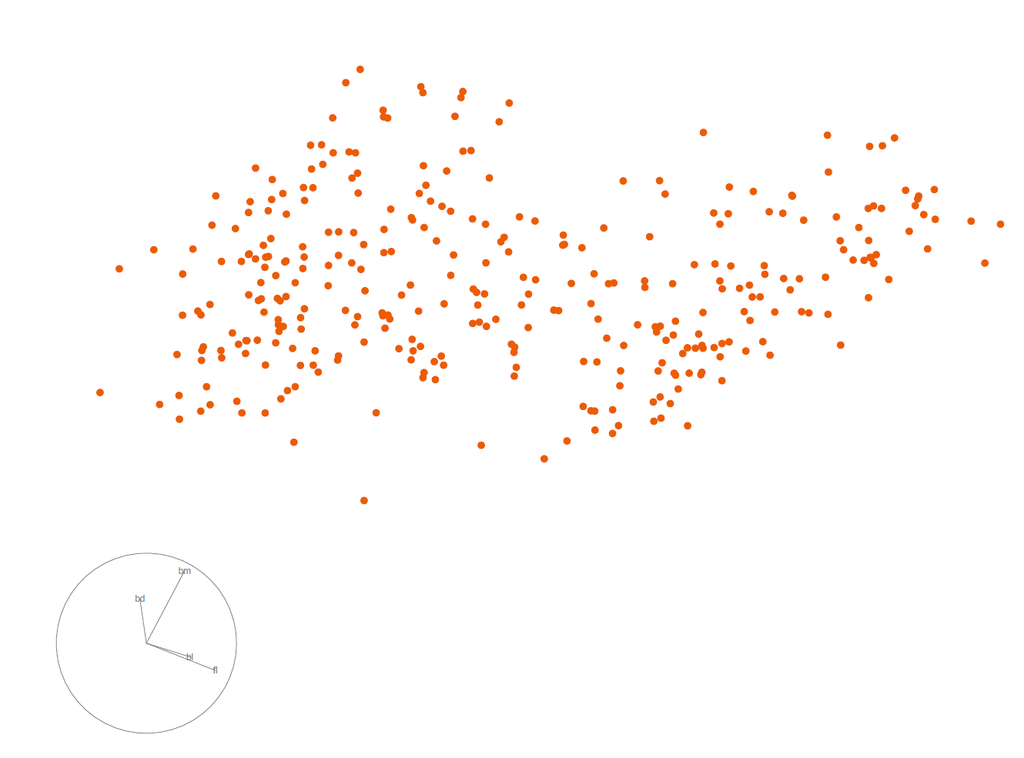

5. Below is another screenshot taken from a tour of the penguins data. In this view of the tour we see evidence that there are at least two clusters in the data. Which variable appears to be driving the clustering structure that we see here the most?

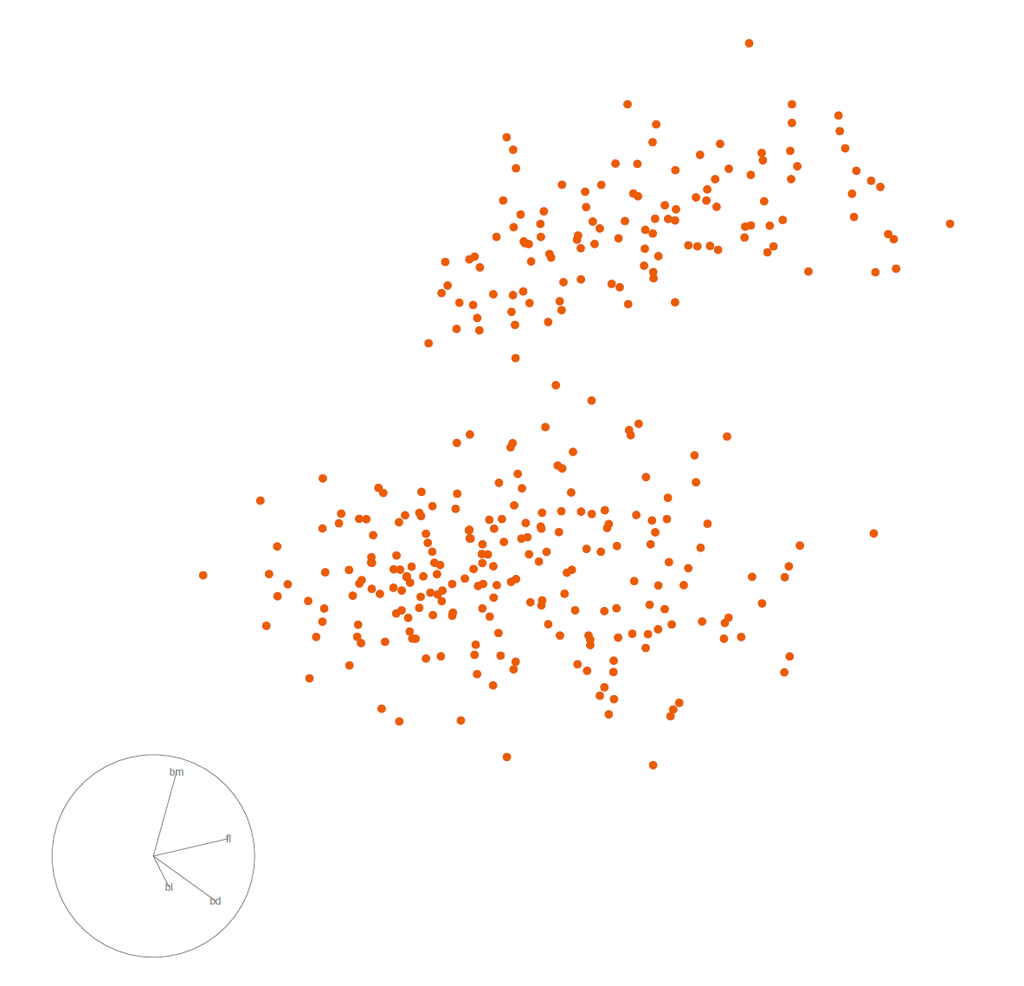

#### 3. Detecting clusters

For the data sets, `c1`, `c3` from the `mulgar` package, use the grand tour to view and try to identify structure (outliers, clusters, non-linear relationships).

**Code to show in a tour**

```r
animate_xy(c1)
animate_xy(c3)
```

#### 4. Effect of covariance

Examine 5D multivariate normal samples drawn from populations with a range of variance-covariance matrices. (You can use the `mvtnorm` package to do the sampling, for example.) Examine the data using a grand tour. What changes when you change the correlation from close to zero to close to 1? Can you see a difference between strong positive correlation and strong negative correlation?

**Code to generate the samples**

```r
library(mvtnorm)
set.seed(501)

s1 <- diag(5)
s2 <- diag(5)
s2[3,4] <- 0.7
s2[4,3] <- 0.7
s3 <- s2
s3[1,2] <- -0.7
s3[2,1] <- -0.7

s1
```

```
     [,1] [,2] [,3] [,4] [,5]
[1,]    1    0    0    0    0
[2,]    0    1    0    0    0
[3,]    0    0    1    0    0
[4,]    0    0    0    1    0
[5,]    0    0    0    0    1
```

**Code to generate the samples**

```r
s2
```

```
     [,1] [,2] [,3] [,4] [,5]
[1,]    1    0  0.0  0.0    0
[2,]    0    1  0.0  0.0    0
[3,]    0    0  1.0  0.7    0
[4,]    0    0  0.7  1.0    0
[5,]    0    0  0.0  0.0    1
```

**Code to generate the samples**

```r
s3
```

```
     [,1] [,2] [,3] [,4] [,5]
[1,]  1.0 -0.7  0.0  0.0    0
[2,] -0.7  1.0  0.0  0.0    0
[3,]  0.0  0.0  1.0  0.7    0
[4,]  0.0  0.0  0.7  1.0    0
[5,]  0.0  0.0  0.0  0.0    1
```

**Code to generate the samples**

```r
set.seed(1234)
d1 <- as.data.frame(rmvnorm(500, sigma = s1))
d2 <- as.data.frame(rmvnorm(500, sigma = s2))
d3 <- as.data.frame(rmvnorm(500, sigma = s3))
```

#### 5. Principal components analysis on the simulated data

🧐 For data sets `d2` and `d3` from Q4 what would you expect would be the number of PCs suggested by PCA?

👨🏽‍💻👩‍💻Conduct the PCA. Report the variances (eigenvalues), and cumulative proportions of total variance, make a scree plot, and the PC coefficients.

#### 6. PCA on cross-currency time series

In Moodle, under Learning -> Getting Started you will find a data folder. Download this folder and you will it that contains the `rates_Nov19_Mar20.csv.csv` data.

The `rates_Nov19_Mar20.csv.csv` data has 152 currencies relative to the USD for the period of Nov 1, 2019 through to Mar 31, 2020. Treating the dates as variables, conduct a PCA to examine how the cross-currencies vary, focusing on this subset: ARS, AUD, BRL, CAD, CHF, CNY, EUR, FJD, GBP, IDR, INR, ISK, JPY, KRW, KZT, MXN, MYR, NZD, QAR, RUB, SEK, SGD, UYU, ZAR.

```r
rates <- read_csv("../data/rates_Nov19_Mar20.csv") |>
  select(date, ARS, AUD, BRL, CAD, CHF, CNY, EUR, FJD, GBP, IDR, INR, ISK, JPY, KRW, KZT, MXN, MYR, NZD, QAR, RUB, SEK, SGD, UYU, ZAR)
```

1. Standardise the currency columns to each have mean 0 and variance 1. Explain why this is necessary prior to doing the PCA or is it? Use this data to make a time series plot overlaying all of the cross-currencies.

**Code to standardise currencies**

```r
library(plotly)
rates_std <- rates |>
  mutate_if(is.numeric, function(x) (x-mean(x))/sd(x))
rownames(rates_std) <- rates_std$date
p <- rates_std |>
  pivot_longer(cols=ARS:ZAR,
               names_to = "currency",
               values_to = "rate") |>
  ggplot(aes(x=date, y=rate,
             group=currency, label=currency)) +
    geom_line()
#ggplotly(p, width=400, height=300)
p
```

[output not shown]

2. Conduct a PCA. Make a scree plot, and summarise proportion of the total variance. Summarise these values and the coefficients for the first five PCs, nicely.

**Code to do PCA and screeplot**

```r
rates_pca <- prcomp(rates_std[,-1], scale=FALSE)
mulgar::ggscree(rates_pca, q=24)
options(digits=2)
summary(rates_pca)
```

[output not shown]

**Code to make a nice summary**

```r
# Summarise the coefficients nicely
rates_pca_smry <- tibble(evl=rates_pca$sdev^2) |>
  mutate(p = evl/sum(evl),
         cum_p = cumsum(evl/sum(evl))) |>
  t() |>
  as.data.frame()
colnames(rates_pca_smry) <- colnames(rates_pca$rotation)
rates_pca_smry <- bind_rows(as.data.frame(rates_pca$rotation),
                            rates_pca_smry)
rownames(rates_pca_smry) <- c(rownames(rates_pca$rotation),
                              "Variance", "Proportion",
                              "Cum. prop")
rates_pca_smry[,1:5]
```

[output not shown]

3. Make a biplot of the first two PCs. Explain what you learn.

**Biplot code**

```r
library(ggfortify)
autoplot(rates_pca, loadings = TRUE,
         loadings.label = TRUE)
```

[output not shown]

4. Make a time series plot of PC1 and PC2. Explain why this is useful to do for this data.

**Code to plot PCs**

```r
rates_pca$x |>
  as.data.frame() |>
  mutate(date = rates_std$date) |>
  ggplot(aes(x=date, y=PC1)) + geom_line()

rates_pca$x |>
  as.data.frame() |>
  mutate(date = rates_std$date) |>
  ggplot(aes(x=date, y=PC2)) + geom_line()
```

[output not shown]

5. You’ll want to drill down deeper to understand what the PCA tells us about the movement of the various currencies, relative to the USD, over the volatile period of the COVID pandemic. Plot the first two PCs again, but connect the dots in order of time. Make it interactive with plotly, where the dates are the labels. What does following the dates tell us about the variation captured in the first two principal components?

**Code to use interaction of the PC plot**

```r
library(plotly)
p2 <- rates_pca$x |>
  as.data.frame() |>
  mutate(date = rates_std$date) |>
  ggplot(aes(x=PC1, y=PC2, label=date)) +
    geom_point() +
    geom_path()
#ggplotly(p2, width=400, height=400)
p2
```

[output not shown]

#### 7. Write a simple question about the week’s material and test your neighbour, or your tutor.

## 👋 Finishing up

Make sure you say thanks and good-bye to your tutor. This is a time to also report what you enjoyed and what you found difficult.